# Exploración de la diversidad metataxonómica

María Sánchez Vivo

2026-05-22

# **Introducción**

En este script se realiza un análisis exploratorio de los datos metataxonómicos obtenidos mediante secuenciación 16S utilizando herramientas del ecosistema *Miaverse*. Para ello, se integran los datos de abundancia, taxonomía y clínicos en un objeto **TreeSummarizedExperiment**. Posteriormente, se analizan métricas de *alfa y beta diversidad* para explorar la diversidad que hay en nuestros datos metataxonomicos entre grupos diagnósticos, empleando índices de riqueza, diversidad y distintas medidas de distancia. Además, se aplican técnicas de reducción de dimensionalidad, como PCoA y UMAP, y se representan los géneros bacterianos más abundantes para explorar la composición de la microbiota en las muestras estudiadas.

```r
library(mia)
library(miaViz)
library(tidyverse)
library(ggpubr)
library(vegan)
library(scater)

# Carga de datos
datos_metabolitos <- readRDS("metabolitos.rds")
datos_metataxonomicos <- readRDS("tax.rds")
datos_clinicos <- readRDS("covs.rds")
datos_abundancia_16S <- readRDS("metagen.rds")
```

Para trabajar con el ecosistema *Miaverse*, es necesario construir un objeto **TreeSummarizedExperiment**, integrando la información de abundancias, taxonomía y variables clínicas en una única estructura de datos.

```r
# CONSTRUCCIÓN DEL TSE
counts_prepared <- datos_abundancia_16S %>%
  column_to_rownames("Sample") %>%
  t() %>%
  as.matrix()

colnames(counts_prepared) <- trimws(colnames(counts_prepared))

datos_clinicos_mia <- as.data.frame(datos_clinicos)
rownames(datos_clinicos_mia) <- trimws(as.character(datos_clinicos_mia$Sample))

tax_prepared <- datos_metataxonomicos %>%
  as.data.frame() %>%
  as.matrix()
rownames(tax_prepared) <- trimws(rownames(tax_prepared))

comun_muestras <- intersect(colnames(counts_prepared), rownames(datos_clinicos_mia))
counts_filtrado <- counts_prepared[, comun_muestras]
clinicos_final  <- datos_clinicos_mia[comun_muestras, ]

comun_taxones <- intersect(rownames(counts_filtrado), rownames(tax_prepared))
counts_final  <- counts_filtrado[comun_taxones, ]
tax_final     <- tax_prepared[comun_taxones, ]

tse <- TreeSummarizedExperiment(
  assays  = list(counts = as.matrix(counts_final)),
  colData = DataFrame(clinicos_final),
  rowData = DataFrame(tax_final)
)

tse <- transformAssay(tse, method = "relabundance")
```

# **Alpha diversidad**

En este apartado se calculan distintos índices de riqueza, diversidad, dominancia y equitatividad con el objetivo de evaluar la variabilidad microbiana dentro de cada muestra (*alpha diversidad*) y comparar los grupos diagnósticos.

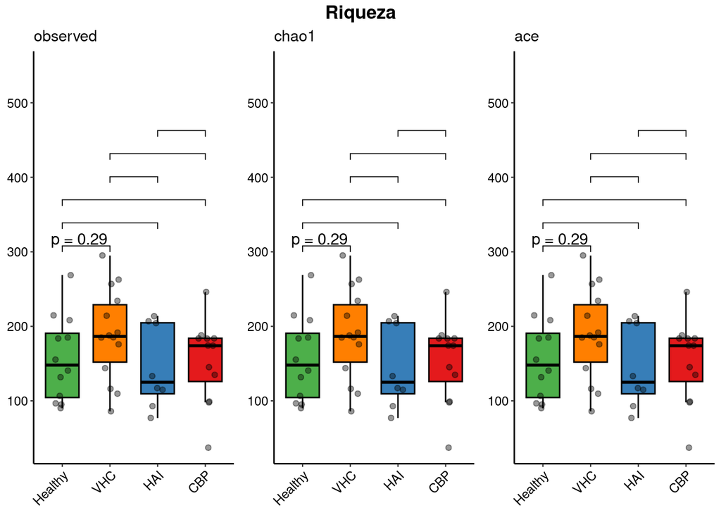

```r
tse <- estimateDiversity(tse, assay.type = "counts",
                         index = c("shannon", "gini_simpson",
                                   "inverse_simpson", "fisher",
                                   "log_modulo_skewness"))

tse <- estimateRichness(tse, assay.type = "counts",
                        index = c("observed", "chao1", "ace"))

tse <- estimateDominance(tse, assay.type = "counts",
                         index = c("absolute", "relative",
                                   "gini", "dmn", "dbp", "simpson_lambda"))

tse <- estimateEvenness(tse, assay.type = "counts",
                        index = c("pielou", "simpson",
                                  "camargo", "evar", "bulla"))


df_alpha <- as.data.frame(colData(tse))

df_alpha$diagnostico_principal <- factor(df_alpha$diagnostico_principal)

niveles_dx <- levels(df_alpha$diagnostico_principal)

paleta_dx <- c("CBP"="#E41A1C","Healthy"="#4DAF4A",
               "HAI"="#377EB8","VHC"="#FF7F00")

todas_comparaciones <- combn(niveles_dx, 2, simplify=FALSE)


#FUNCIÓN DE PLOTS
plot_alpha <- function(indice, df, grupo="diagnostico_principal") {

  if (!indice %in% colnames(df)) return(NULL)

  val_max <- max(df[[indice]], na.rm = TRUE)

  ggboxplot(df,
            x=grupo,
            y=indice,
            fill=grupo,
            add="jitter",
            add.params=list(alpha=0.4, size=1.5)) +
    scale_fill_manual(values=paleta_dx) +

    stat_compare_means(method="kruskal.test",
                       label="p.format",
                       label.y = val_max * 1.05) +

    stat_compare_means(comparisons=todas_comparaciones,
                       method="wilcox.test",
                       label="p.signif",
                       hide.ns=TRUE) +
    theme_pubr(base_size=9) +
    theme(axis.text.x=element_text(angle=45, hjust=1),
          legend.position="none") +
    labs(title=indice, x=NULL, y=NULL) +

    scale_y_continuous(expand = expansion(mult = c(0.05, 0.25)))
}


#RIQUEZA: Cuenta el número total de OTUs de cada muestra
ggarrange(
  plotlist = Filter(Negate(is.null),
                    lapply(c("observed","chao1","ace"),
                           plot_alpha, df=df_alpha)),
  ncol=3,nrow=1
) %>%
  annotate_figure(top=text_grob("Riqueza",face="bold",size=13))
```

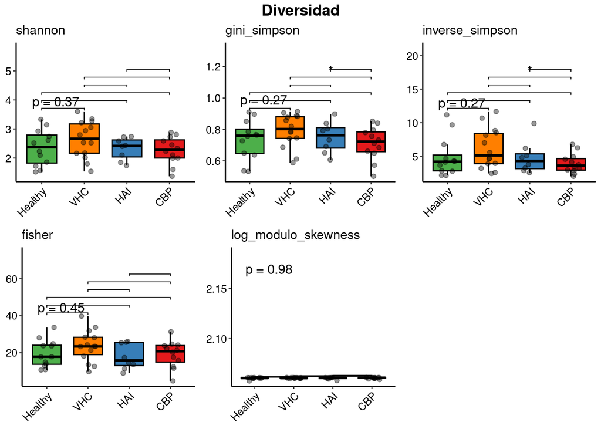

```r
#DIVERSIDAD: mide cuántos OTUs hay y cómo se distribuyen sus abundancias dentro de cada muestra
ggarrange(
  plotlist = Filter(Negate(is.null),
                    lapply(c("shannon","gini_simpson","inverse_simpson",
                             "fisher","log_modulo_skewness"),
                           plot_alpha, df=df_alpha)),
  ncol=3,nrow=2
) %>%
  annotate_figure(top=text_grob("Diversidad",face="bold",size=13))
```

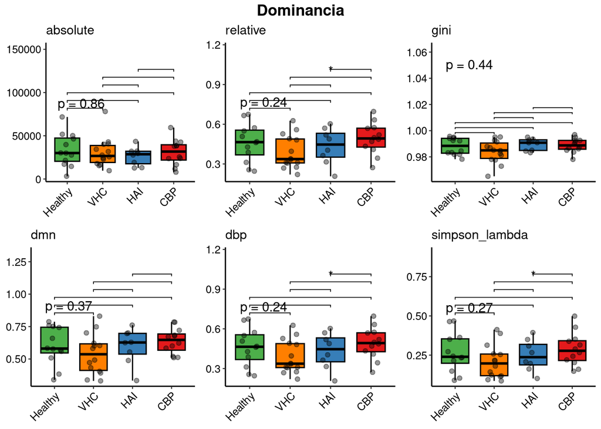

```r
#DOMINANCIA: mide si unas pocas OTUs concentran la mayor parte de la abundancia en la muestra
ggarrange(
  plotlist = Filter(Negate(is.null),
                    lapply(c("absolute","relative","gini",
                             "dmn","dbp","simpson_lambda"),
                           plot_alpha, df=df_alpha)),
  ncol=3,nrow=2
) %>%
  annotate_figure(top=text_grob("Dominancia",face="bold",size=13))
```

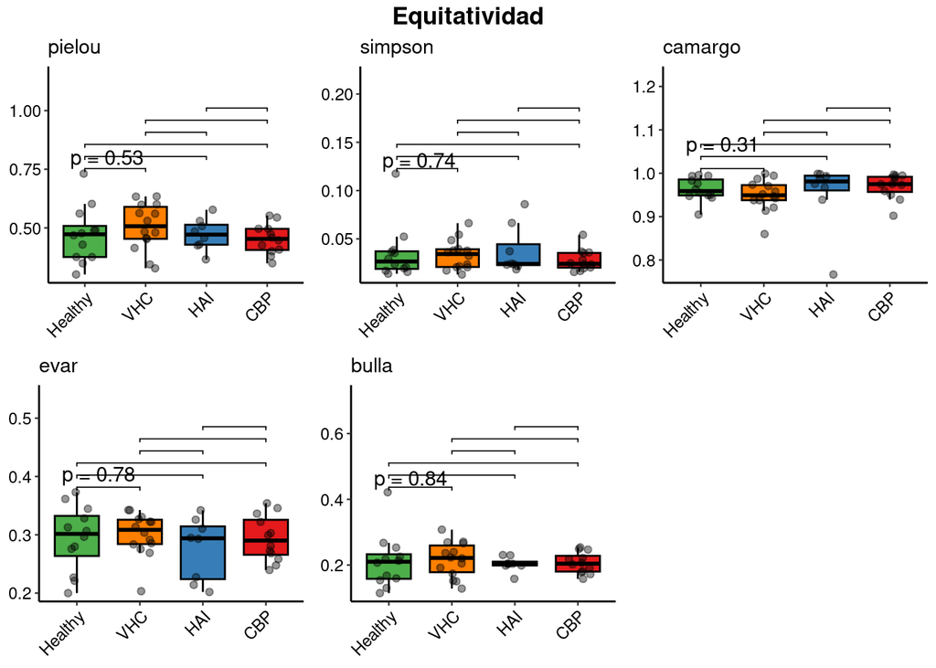

```r
#EQUITATIVIDAD: mide si todos los OTUs tienen abundancias parecidas
ggarrange(
  plotlist = Filter(Negate(is.null),
                    lapply(c("pielou","simpson","camargo",
                             "evar","bulla"),
                           plot_alpha, df=df_alpha)),
  ncol=3,nrow=2
) %>%
  annotate_figure(top=text_grob("Equitatividad",face="bold",size=13))
```

# **Beta diversidad**

## Disimilitud de Brays-Curtis

La *beta diversidad* es la comparación entre diferentes muestras (si son parecidas o diferentes) y se evalúa en este apartado utilizando la *distancia Bray-Curtis sobre abundancias relativas*, representando las diferencias entre muestras mediante un análisis PCoA y validándolas con PERMANOVA.

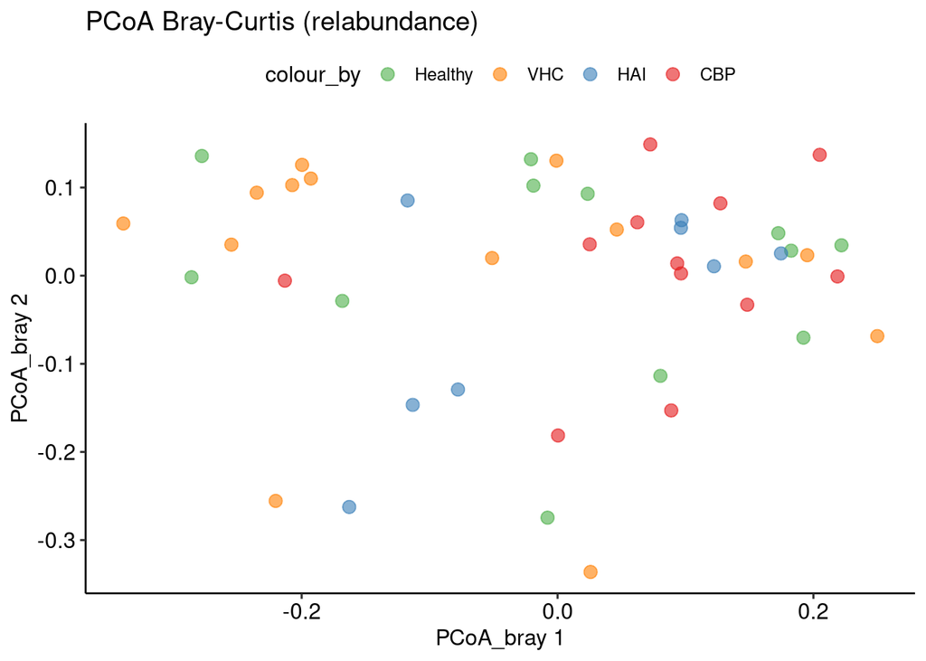

```r
tse_bray <- transformAssay(tse, method = "relabundance")

tse_bray <- runMDS(
  tse_bray,
  FUN = vegan::vegdist,
  method = "bray",
  assay.type = "relabundance",
  name = "PCoA_bray"
)

p_bray <- plotReducedDim(
  tse_bray,
  "PCoA_bray",
  colour_by = "diagnostico_principal",
  point_size = 3
)

p_bray +
  scale_color_manual(values = paleta_dx) +
  theme_pubr() +
  labs(title = "PCoA Bray-Curtis (relabundance)")
```

```r
# PERMANOVA
dist_bray <- vegdist(
  t(assay(tse_bray, "relabundance")),
  method = "bray"
)

set.seed(123)
adonis2(
  dist_bray ~ diagnostico_principal,
  data = as.data.frame(colData(tse_bray)),
  permutations = 999
)
```

```
## Permutation test for adonis under reduced model
## Permutation: free
## Number of permutations: 999
##
## adonis2(formula = dist_bray ~ diagnostico_principal, data = as.data.frame(colData(tse_bray)), permutations = 999)
##          Df SumOfSqs    R2      F Pr(>F)
## Model     3   0.2815 0.073 1.1024  0.318
## Residual 42   3.5743 0.927
## Total    45   3.8557 1.000
```

Tanto el **PCoA de Bray-Curtis** como la prueba matemática de **PERMANOVA** (*adonis2*) demuestran de forma contundente que **no existen diferencias significativas** en la composición global de la microbiota entre los grupos (p = 0.318). El diagnóstico principal solo explica el **7.3%** de la variabilidad de las comunidades bacterianas (R^2 = 0.073), dejando el 92.7% restante a la propia variabilidad interindividual. Esto se refleja visualmente en el gráfico, donde los puntos de las diferentes condiciones aparecen completamente dispersos y solapados entre sí, sin formar agrupaciones independientes.

## Distancia Jaccard

Posteriormente, se realiza un análisis basado en la *distancia Jaccard*, utilizando datos de presencia/ausencia para estudiar diferencias composicionales entre grupos diagnósticos.

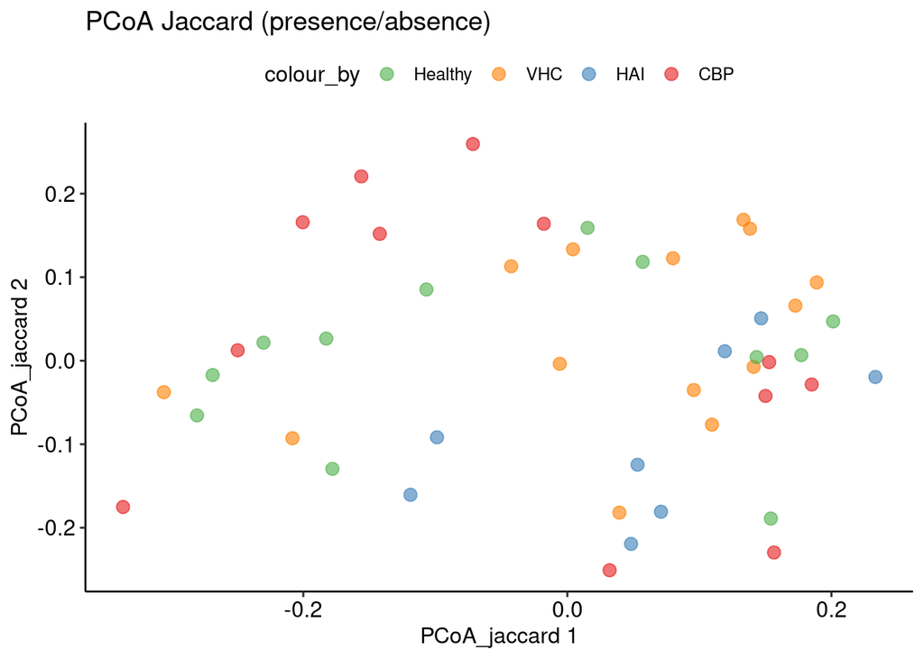

```r
tse_pa <- transformAssay(tse, method = "pa")

tse_pa <- runMDS(
  tse_pa,
  FUN = vegan::vegdist,
  method = "jaccard",
  assay.type = "pa",
  name = "PCoA_jaccard"
)

p_jaccard <- plotReducedDim(
  tse_pa,
  "PCoA_jaccard",
  colour_by = "diagnostico_principal",
  point_size = 3
)

p_jaccard +
  scale_color_manual(values = paleta_dx) +
  theme_pubr() +
  labs(title = "PCoA Jaccard (presence/absence)")
```

```r
# PERMANOVA
dist_jaccard <- vegdist(
  t(assay(tse_pa, "pa")),
  method = "jaccard",
  binary = TRUE
)

set.seed(123)
adonis2(
  dist_jaccard ~ diagnostico_principal,
  data = as.data.frame(colData(tse_pa)),
  permutations = 999
)
```

```
## Permutation test for adonis under reduced model
## Permutation: free
## Number of permutations: 999
##
## adonis2(formula = dist_jaccard ~ diagnostico_principal, data = as.data.frame(colData(tse_pa)), permutations = 999)
##          Df SumOfSqs      R2     F Pr(>F)
## Model     3   0.9148 0.07002 1.054  0.189
## Residual 42  12.1500 0.92998
## Total    45  13.0647 1.00000
```

El **PCoA** basado en la distancia de **Jaccard** evalúa la beta diversidad centrándose exclusivamente en la **presencia o ausencia** de taxones bacterianos, ignorando sus abundancias relativas. Los resultados de la prueba de **PERMANOVA** (*adonis2*) determinan que **no existen diferencias estadísticas significativas** en la composición cualitativa de la microbiota entre los grupos (p = 0.189). Similar al análisis anterior, el diagnóstico principal solo explica el **7.0%** de la varianza total (R^2 = 0.070), por lo que el 93% se debe a la variabilidad interindividual de los pacientes. Es por ello que en el gráfico bidimensional las muestras de todos los grupos no muestran ningún patrón de agrupación, es decir, no hay diferencias entre grupos.

## Distancia de Aitchison

Dado que los datos microbiológicos son composicionales, también se aplica una *transformación CLR y la distancia de Aitchison*, considerada una aproximación adecuada para este tipo de datos.

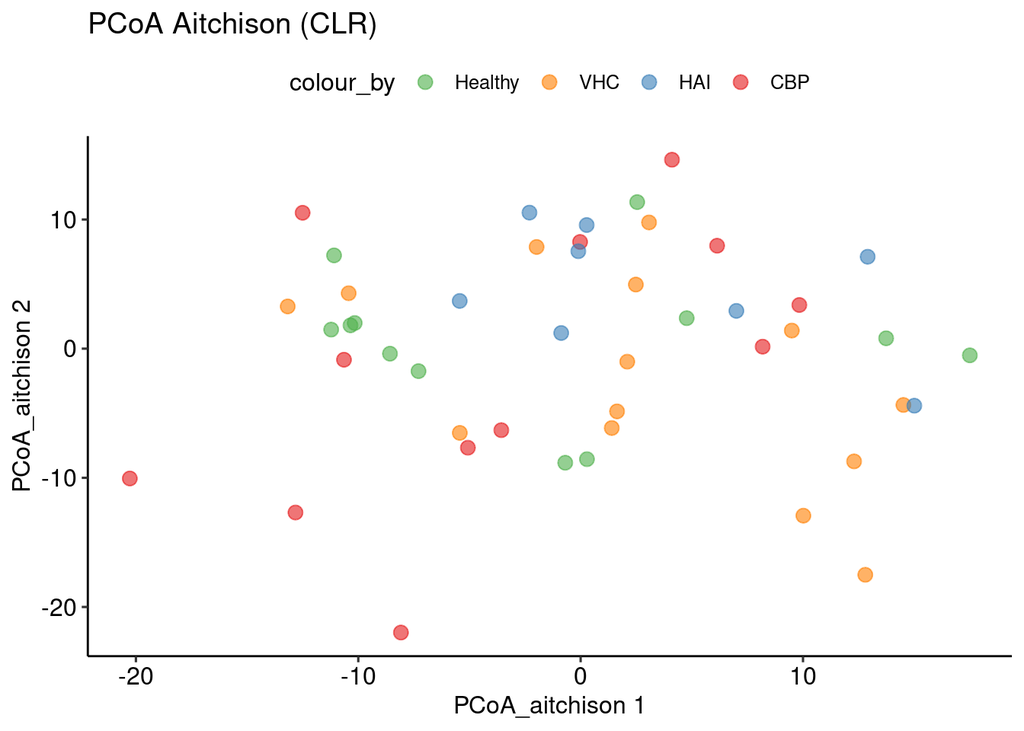

```r
tse_clr <- transformAssay(tse, method = "clr", pseudocount = 1)

# PCoA / MDS con distancia euclídea sobre CLR (Aitchison)
tse_clr <- runMDS(
  tse_clr,
  FUN = stats::dist,
  method = "euclidean",
  assay.type = "clr",
  name = "PCoA_aitchison"
)

# Visualización
p_aitchison <- plotReducedDim(
  tse_clr,
  "PCoA_aitchison",
  colour_by = "diagnostico_principal",
  point_size = 3
)

p_aitchison +
  scale_color_manual(values = paleta_dx) +
  theme_pubr() +
  labs(title = "PCoA Aitchison (CLR)")
```

```r
# Distancia Aitchison (coherente con CLR)
dist_aitchison <- dist(
  t(assay(tse_clr, "clr")),
  method = "euclidean"
)

# PERMANOVA
set.seed(123)
adonis2(
  dist_aitchison ~ diagnostico_principal,
  data = as.data.frame(colData(tse_clr)),
  permutations = 999
)
```

```
## Permutation test for adonis under reduced model
## Permutation: free
## Number of permutations: 999
##
## adonis2(formula = dist_aitchison ~ diagnostico_principal, data = as.data.frame(colData(tse_clr)), permutations = 999)
##          Df SumOfSqs      R2      F Pr(>F)
## Model     3     4088 0.06866 1.0321  0.305
## Residual 42    55447 0.93134
## Total    45    59535 1.00000
```

El **PCoA** basado en la distancia de **Aitchison** (utilizando la transformación CLR) evalúa la beta diversidad abordando la naturaleza composicional de los datos de secuenciación. En consonancia con las métricas anteriores, la prueba de **PERMANOVA** (*adonis2*) confirma la **ausencia de diferencias estadísticas significativas** en la estructura global de la microbiota entre los grupos (p = 0.305). El diagnóstico principal explica únicamente el **6.8%** de la varianza total (R^2 = 0.068), dejando el 93.1% restante a la variabilidad intrínseca interindividual y un solapamiento de muestras sin formar clústeres independientes.

## UMAP - paquete uwot

Con el objetivo de explorar posibles agrupamientos entre muestras, se aplica el *algoritmo UMAP* utilizando la implementación del paquete **uwot**.

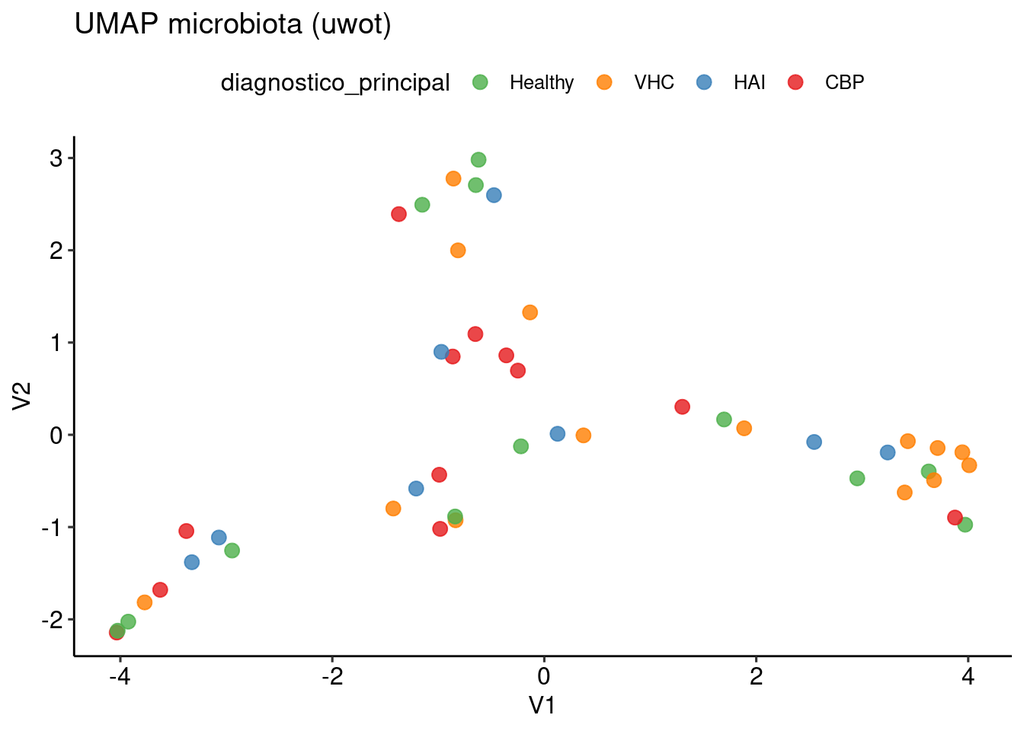

```r
library(uwot)

mat <- t(assay(tse, "relabundance"))

set.seed(123)
umap_res <- umap(
  mat,
  n_neighbors = 5  # Probar 1, 3, 5, 7
)

df_umap <- as.data.frame(umap_res)
df_umap$diagnostico_principal <- colData(tse)$diagnostico_principal

ggplot(df_umap, aes(V1, V2, color = diagnostico_principal)) +
  geom_point(size = 3, alpha = 0.8) +
  scale_color_manual(values = paleta_dx) +
  theme_pubr() +
  labs(title = "UMAP microbiota (uwot)")
```

El gráfico de reducción de dimensionalidad no lineal **UMAP** corrobora de manera visual los resultados previos de las métricas de beta diversidad **(Bray-Curtis, Jaccard y Aitchison)**. Aunque esta técnica es altamente sensible para capturar estructuras complejas y agrupamientos locales en los datos de la microbiota, se observa que los puntos representativos de los cuatro grupos **(Healthy, VHC, HAI y CBP)** aparecen dispersos de forma homogénea y mezclados en todas las agrupaciones que proyecta el mapa. Esta falta de separación por colores confirma de manera definitiva que **el diagnóstico principal no es un factor determinante en la conformación de la microbiota intestinal**, prevaleciendo la variabilidad interindividual de los pacientes sobre el estado de la patología hepática.

## UMAP - ecosistema Miaverse

Para comparar la representación obtenida previamente y reforzar la confirmación realizada, también se realiza un segundo análisis UMAP utilizando las funciones integradas de *Miaverse*.

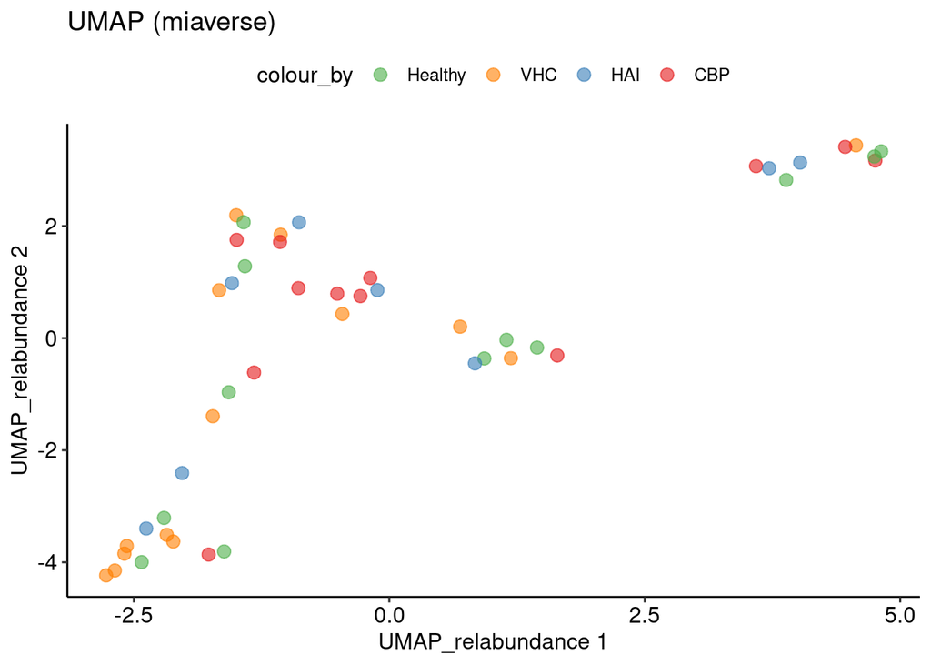

```r
# UMAP usando función runUMAP de miaverse.

tse_umap <- transformAssay(tse, method = "relabundance")

set.seed(123)
tse_umap <- runUMAP(
  tse_umap,
  assay.type = "relabundance",
  n_neighbors = 5,   # puedes probar 1, 3, 5, 7
  name = "UMAP_relabundance"
)

# Plot
p_umap <- plotReducedDim(
  tse_umap,
  "UMAP_relabundance",
  colour_by = "diagnostico_principal",
  point_size = 3
)

p_umap +
  scale_color_manual(values = paleta_dx) +
  theme_pubr() +
  labs(title = "UMAP (miaverse)")
```

# **Agrupación por género**

Finalmente, los datos se *agrupan a nivel de género* y se seleccionan los *10 géneros con mayor abundancia relativa media* para representar su distribución entre muestras y diagnósticos.

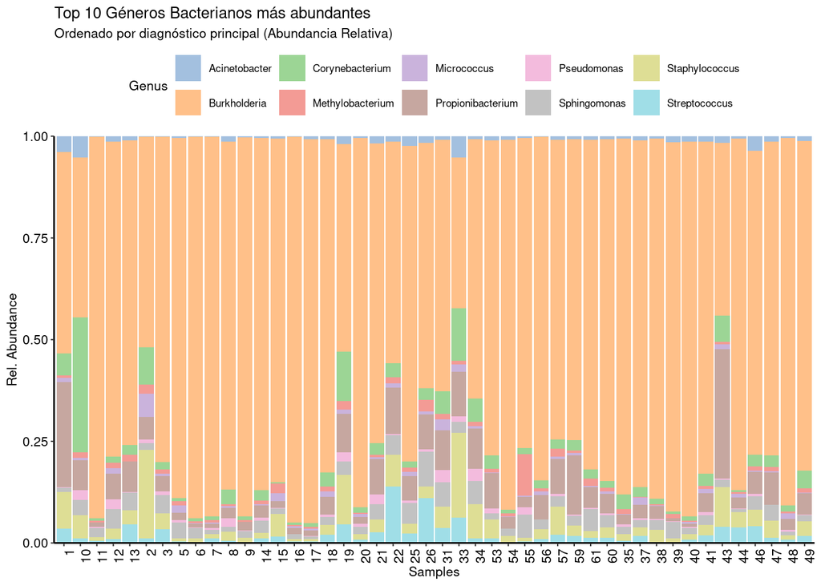

```r
tse_genus <- agglomerateByRank(tse, rank="Genus")
tse_genus <- tse_genus[rowData(tse_genus)$Genus!="",]
tse_genus <- transformAssay(tse_genus, method="relabundance")

abund_mean <- rowMeans(assay(tse_genus,"relabundance"))
top10 <- names(sort(abund_mean,decreasing=TRUE))[1:10]

tse_genus_top <- tse_genus[top10,]

plotAbundance(tse_genus_top,
              assay.type="relabundance",
              rank="Genus",
              order_sample_by="diagnostico_principal") +
  theme_pubr(base_size=8) +
  theme(axis.text.x=element_text(angle=90,hjust=1)) +
  labs(title    = "Top 10 Géneros Bacterianos más abundantes",
    subtitle = "Ordenado por diagnóstico principal (Abundancia Relativa)")
```

Este gráfico de barras apiladas revela un perfil taxonómico caracterizado por el dominio absoluto y generalizado del género *Burkholderia*, el cual representa más del 50% —y frecuentemente hasta el 95%— de la abundancia relativa en casi todas las muestras. La variabilidad interindividual restante está marcada por géneros secundarios que emergen de forma notable en sujetos específicos, destacando picos de *Corynebacterium* y *Propionibacterium*, mientras que una comunidad minoritaria y heterogénea de bacterias como *Staphylococcus*, *Streptococcus*, *Sphingomonas* y *Methylobacterium* complementa la base del ecosistema.